# Task 4

Kornelijus Samsonas

- **Užduotis:** Aplanke task4 yra duomenų failas, kuriame rasite nekilnojamo turto (o tiksliau gyvenamujų butų) kainas ir kai kurias jų charakteristikas. Jūsų užduotis atlikti išsamia tiesine regresiją. Lygtis reikalinga prekyboms agentams, kad geriau suprastų kokią įtaką skirtingos charakteristikos daro galutinei kainai.
- Nuskaitome duomenis

```r
setwd("~/Desktop/Ekonometrija/Ekonometrija 4 semestras/Praktine ekonometrija/Econometrics/task4")
datafull <- read.csv2("data.csv")
```

- Tikrinsime kintamujų multikoliniarumą. Tinkama priemonė patikrinti, ar modelyje egzistuoja multikolinearumo problema, yra (VIF) funkcija. Jei kuris nors funkcijos VIF pateiktas koeficientas yra > 10, galime teigti kad modelyje egzistuoja multikolinearumo problema. Kad galėtume naudoti funkcija VIF, reikės parsisiusti paketą {usdm}.

```r
library(usdm)
vif(datafull)
```

```
##                   Variables       VIF
## 1                     kaina  4.675778
## 2                    plotas  4.283969
## 3                   aukstas  1.082947
## 4           garsoIzoliacija 11.282639
## 5           silumosLaidumas 11.029037
## 6 atstumasIkiPrekybosCentro  1.008829
```

```r
#Dviejų kintamujų (garsoIzoliacija ir silumosLaidumas) VIF > 10, tai sufleruoja apie egzistuojantį multikolinearumą.

cor(datafull$garsoIzoliacija, datafull$silumosLaidumas)
```

```
## [1] 0.9535669
```

```r
# Kintamieji (garsoIzoliacija ir silumosLaidumas) koreliuoja labai stipriai (cor = 0.9535669), todėl užtenka naudoti tik vieną jų.

dataout <- datafull[,-4]
#Perkant bustą, labiau atsižvelgiama į šilumos laidumą, todėl išmetame garsoIzoliacija iš pateiktų duomenų.

vif(dataout)#Duomenyse be kintamojo (garsoIzoliacija) multikolinearumo problema išnyksta.
```

```
##                   Variables      VIF
## 1                     kaina 4.588859
## 2                    plotas 4.236473
## 3                   aukstas 1.074000
## 4           silumosLaidumas 1.210216
## 5 atstumasIkiPrekybosCentro 1.008817
```

- Ieškosime išskircių duomenyse.

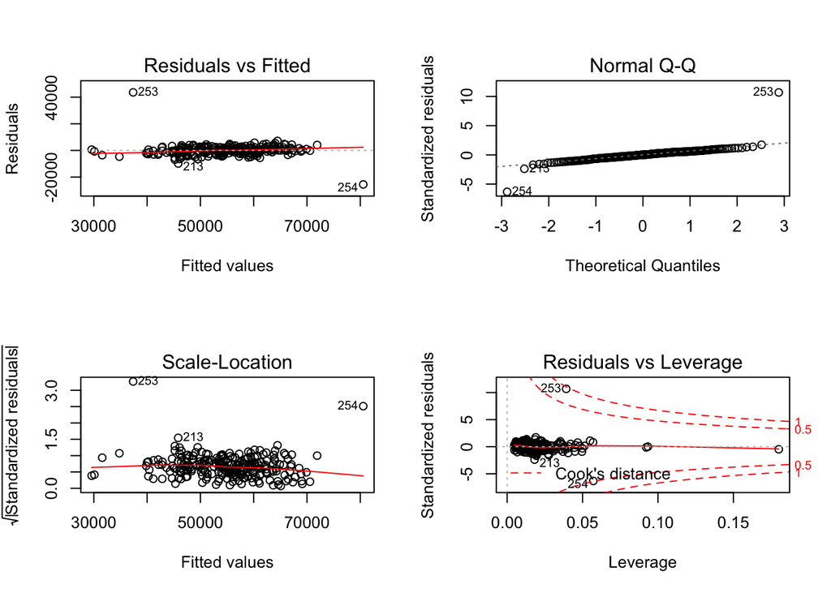

```r
mod1 <- lm(kaina ~ plotas + aukstas + silumosLaidumas + atstumasIkiPrekybosCentro, data = dataout)
par(mfrow = c(2,2))
plot(mod1)#Sudarę modelį išbrėžiame modelio grafikus. Galime pastebėti potencialias išskirtis nr. 253 ir 254).
```

```r
#Norint suranti išskirtis naudosime outlierTest funkciją esančia pakete {car}.
library(car)
outlierTest(mod1)#Ši funkcija identifikuoja išskirtis. 253 ir 254 eilutėse esantys duomenys yra išskirtys.
```

```
##      rstudent unadjusted p-value Bonferonni p
## 253 14.486648         7.1195e-35   1.8084e-32
## 254 -6.882738         4.7778e-11   1.2136e-08
```

```r
data <- dataout[-c(253, 254),] #Pašaliname išskirtis.
```

- Tikrinsime heteroskedastiškumą.

```r
mod2 <- lm(kaina ~ plotas + aukstas + silumosLaidumas + atstumasIkiPrekybosCentro, data = data)
#Sukuriame naują modelį (naudojame duomenis be išskirčių).

ncvTest(mod2)
```

```
## Non-constant Variance Score Test
## Variance formula: ~ fitted.values
## Chisquare = 2.742328    Df = 1     p = 0.0977223
```

```r
#Ši funkcija atlieka testą su hipoteze H0, kad modelis homoskedastiškas ir alternatyva H1, kad modelis heteroskedastiškas.
#p-value > 0.05, todėl priimame H0 hipotezę. Galime teigti, kad modelis nėra heteroskedastiškas.
```

- Pašalinsime modelyje esančius nereikšmingus narius.

```r
summary(mod2)
```

```
##
## Call:
## lm(formula = kaina ~ plotas + aukstas + silumosLaidumas + atstumasIkiPrekybosCentro,
##     data = data)
##
## Residuals:
##    Min     1Q Median     3Q    Max
##  -9212  -1540     92   1789   5862
##
## Coefficients:
##                           Estimate Std. Error t value Pr(>|t|)
## (Intercept)                7966.67     977.86   8.147 1.86e-14 ***
## plotas                      599.37      12.13  49.410  < 2e-16 ***
## aukstas                     318.66      63.49   5.019 9.95e-07 ***
## silumosLaidumas             527.45      47.52  11.099  < 2e-16 ***
## atstumasIkiPrekybosCentro    85.45      81.38   1.050    0.295
## ---
## Signif. codes:  0 '***' 0.001 '**' 0.01 '*' 0.05 '.' 0.1 ' ' 1
##
## Residual standard error: 2547 on 247 degrees of freedom
## Multiple R-squared:  0.9162, Adjusted R-squared:  0.9149
## F-statistic: 675.5 on 4 and 247 DF,  p-value: < 2.2e-16
```

```r
#Kintamojo atstumasIkiPrekybosCentro p-value = 0.295, tai leidžia teigti, kad jis nereikšmingas (p-value > 0.05). Šaliname šį kintamajį.

mod3 <- lm(kaina ~ plotas + aukstas + silumosLaidumas, data = data)
summary(mod3)
```

```
##
## Call:
## lm(formula = kaina ~ plotas + aukstas + silumosLaidumas, data = data)
##
## Residuals:
##     Min      1Q  Median      3Q     Max
## -9323.0 -1579.4   114.8  1747.6  5759.2
##
## Coefficients:
##                 Estimate Std. Error t value Pr(>|t|)
## (Intercept)      8035.80     975.85   8.235 1.04e-14 ***
## plotas            600.33      12.10  49.622  < 2e-16 ***
## aukstas           318.23      63.50   5.011 1.03e-06 ***
## silumosLaidumas   528.82      47.51  11.130  < 2e-16 ***
## ---
## Signif. codes:  0 '***' 0.001 '**' 0.01 '*' 0.05 '.' 0.1 ' ' 1
##
## Residual standard error: 2548 on 248 degrees of freedom
## Multiple R-squared:  0.9159, Adjusted R-squared:  0.9149
## F-statistic: 899.9 on 3 and 248 DF,  p-value: < 2.2e-16
```

```r
# Naujame modelyje nereikšmingų narių nebėra.
```

- Tikrinsime autokoreliacijas.

```r
durbinWatsonTest(mod3)#Ši funkcija patikrina, ar liekanos autokoreliuoja.
```

```
##  lag Autocorrelation D-W Statistic p-value
##    1      0.05475525      1.885685   0.372
##  Alternative hypothesis: rho != 0
```

```r
#p-value > 0.05, galime teigti, kad liekanos nėra autokorealiuotos.
```

- Brėžiame mod3 liekanų histogramą ir tankio funkciją. Galime matyti,kad liekanos pasiskirsčiusios pagal normalujį skirstinį.

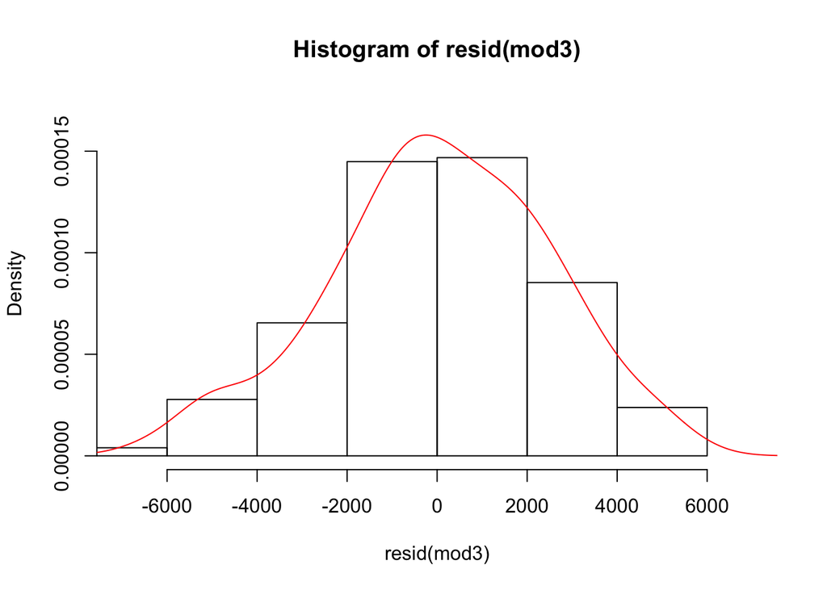

- AKAIKE’S kriterijus “baudžia” už kiekvieną papildomai į modelį itrauktą nereikšmingą narį, todėl šis kriterijus yra vienas geriausių norint palyginti kelių modelių tikslumą. Kuo mažesnis AKAIKE koeficientas, tuo modelis yra tikslesnis.

```r
AIC(mod1)
```

```
## [1] 4961.728
```

```r
AIC(mod2)
```

```
## [1] 4674.872
```

```r
AIC(mod3)
```

```
## [1] 4673.994
```

```r
#Matome, kad mod3 modelio AKAIKE mažiausia. Galime teigti, kad šis modelis tiksliausiai aprašo iš ko susideda kaina.
```

```r
summary(mod3)
```

```
##
## Call:
## lm(formula = kaina ~ plotas + aukstas + silumosLaidumas, data = data)
##
## Residuals:
##     Min      1Q  Median      3Q     Max
## -9323.0 -1579.4   114.8  1747.6  5759.2
##
## Coefficients:
##                 Estimate Std. Error t value Pr(>|t|)
## (Intercept)      8035.80     975.85   8.235 1.04e-14 ***
## plotas            600.33      12.10  49.622  < 2e-16 ***
## aukstas           318.23      63.50   5.011 1.03e-06 ***
## silumosLaidumas   528.82      47.51  11.130  < 2e-16 ***
## ---
## Signif. codes:  0 '***' 0.001 '**' 0.01 '*' 0.05 '.' 0.1 ' ' 1
##
## Residual standard error: 2548 on 248 degrees of freedom
## Multiple R-squared:  0.9159, Adjusted R-squared:  0.9149
## F-statistic: 899.9 on 3 and 248 DF,  p-value: < 2.2e-16
```

- **Išvados:** Modelyje mod3 esantys kintamieji paaiškina apie 91% kainos (pagal $R^2$ ). Pagal modelio apskaičiuotus įvertinius galime teigti: 1 kv.m padidėjimas padidina kaina 600,33 eurais, kiekvienas aukšto padidėjimas 1 aukštu kainą padidina 318,23 eurais, 1 vnt. šilumos laidumo koeficiento padidėjimas padidina kainą 528,82 eurais. Laisvasis narys sudaro 8035,80 eurus tai galėtume interpretuoti kaip papildomas išlaidos, kurios atsiranda pardavimo metu pvz. notaro paslaugos ir t.t..